# Avaliação dos Programas de Pós-graduação Engenharia Biomédica, Engenharia de Sistemas Eletrônicos e de Automação, Engenharia Elétrica P7 e Engenharia Elétrica P8 e dos Currículos dos Professores e Pesquisadores Cadastrados

Tópicos Avançados em Computadores CIC/UnB 2018.2 Turma D “Ciência de Dados para Todos (Data Science For All)”. Professor Ricardo Barros Sampaio e Professor Jorge Henrique Cabral Fernandes.

Marcos Vinicius Prescendo Tonin 14/0153233, Lucas Nascimento Santos Souza 14/0151010 e Carlos Aragão

02/12/2018

# I - Introdução

O presente trabalho tem por finalidade entender, correlacionar e analisar os dados da produção acadêmica e científica dos seguintes cursos de pós-graduação: Engenharia Biomédica, Engenharia Elétrica em seus dois ramos (53001010059P8 e 53001010080P7) e Engenharia de Sistemas Eletrônicos e de Automação.

# II - Metodologia

Para um melhor resultado do trabalho buscou-se seguir e adaptar-se a metodologia CRISP-DM, para isso baseou-se no ciclo de projeto da metodologia CRISP-DM.

O ciclo é definido pelas seguintes fases:

- **Entendimento do negócio**: Primeiramente deve-se entender o que se busca encontrar, haja visto que não faz sentido fazer uma análise de dados sem saber o que se busca.
- **Entendimento dos dados**: Busca-se entender os dados de forma mais superficial inicialmente.
- **Preparação de dados**: Então os dados são tratados para que se possa facilitar o processamento dos mesmos.
- **Modelagem**: Realiza a modelagem do dado.
- **Avaliação**: Avalia-se o resultado da modelagem.
- **Implatação**: Utilização dos dados.

Para melhor visualização das fases e a comunicação entre elas, deves-se observar a Figura 1. Por esta figura consegue-se perceber que, por exemplo, o entendimento do negócio e do dado pode muitas vezes ser se alternar no ciclo da metodologia adotada.

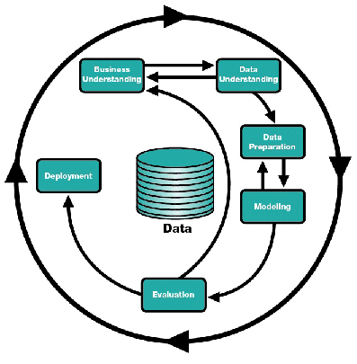

Ciclo do CRISP-DM que será usado como base

# III - Delimitações iniciais

## III.1 - Domínio de Aplicação do projeto

O domínio de Aplicação do projeto é a produção científica e acadêmica dos docentes e discentes dos seguintes cursos de pós-graduação da Universidade de Brasília: **Engenharia Biomédica**,**Engenharia Elétrica P7 e P8** e **Engenharia de Sistemas Eletrônicos e de Automação**. Os dados para análise foram obtidos a partir da plataforma elattes e da plataforma sucupira.

## III.2 - Problema abordado

O problema tem por finalidade obter dados de forma descritiva, quantitativa e de modelagem computacional ou estatística, que permitam caracterizar como, porque e também para que ocorre a produção científica e acadêmica nos cursos de pós-graduação descritos anteriormente.

### Engenharia Biomédica

O programa de pós-graduação da engenharia biomédica - possui as informações: Código: 53001010083P6; Área-base: 31300006.

Numero de disciplina retirado do site https://fga.unb.br/pgengbiomedica/lista-de-oferta : 9 disciplinas.

Na área de concetração engenharia biomédica, há 4 áreas(linhas) de pesquisa:

- Análise e Desenvolvimento de Sistemas Inteligentes e de Saúde : " Relaciona os aspectos ligados à análise, desenvolvimento, aquisição, representação e descoberta do conhecimento para a produção de sistemas inteligentes e de saúde. É uma área multidisciplinar, que apoia a tomada de decisão, diagnóstico, tratamento e desenvolvimento de técnicas para prática na saúde. Aborda os principais avanços teóricos e práticos de metodologias e técnicas utilizadas no desenvolvimento de Sistemas Inteligentes e de Saúde. As principais áreas de investigação são: Análise e modelagem de dados epidemiológicos; Análise de sistemas de saúde; Gestão e avaliação de tecnologias em saúde; Engenharia Clínica; Inteligência Artificial; Aprendizado de Máquina; Sistemas Baseados em Conhecimento; Paradigmas Simbólicos; Conexionistas, Evolutivos e Híbridos; Inteligência Computacional; Nanotecnologia; entre outras."
- Física Médica e Bioengenharia. " Relaciona a aplicação e as consequências das radiações ionizantes e não ionizantes na área da saúde, que a cada dia se tornam mais complexas e desafiadoras. Isso exige que os profissionais da área possuam uma formação específica de grande qualidade em diferentes campos, tais como física, biologia e química. Ademais, estes profissionais devem dominar os fundamentos de proteção radiológica e conhecer normas nacionais e recomendações internacionais a ela relacionadas, visando a sua própria proteção, bem como à proteção do paciente, do público geral e do meio ambiente. "
- Sistemas Eletrônicos e Instrumentação Biomédica : " Abrange a pesquisa e o desenvolvimento de transdutores, equipamentos, aparelhos ou sistemas microprocessados de uso biológico ou aplicação médica, odontológica ou laboratorial. A linha aborda o desenvolvimento e análise tanto de software como de hardware, abrangendo componentes e técnicas de microeletrônica, circuitos integrados e dispositivos programáveis. A ênfase diz respeito a aplicações em prevenção, diagnóstico, tratamento ou reabilitação. Em comparação com outros produtos de engenharia, a instrumentação biomédica se distingue por obter seus sinais de entrada a partir de seres vivos ou seus extratos, e ainda por aplicar energia (eletromagnética, mecânica, térmica) diretamente a tecidos vivos. As principais áreas de investigação são: Desenvolvimento de eletrodos ativos; Aquisição de sinais biológicos e biomédicos; Estimulação de tecidos ou sistemas biológicos e biomédicos; Desenvolvimento e análise de dispositivos microeletrônicos; Projetos e configuração de dispositivos programáveis; Projeto de circuitos integrados. "
- Processamento de Sinais e Imagens : “: Sinais e imagens são representações da realidade, na forma de funções matemáticas a serem submetidas a métodos rigorosos e eficientes de extração e tratamento de informação. Pode-se definir um sinal como um conjunto físico, abstrato ou simbólico de dados de interesse específico (i.e., informação) que muda ao longo do tempo ou do espaço. Uma imagem, especificamente, é conceituada como uma representação visual, real ou pictórica, parcial ou total, de uma estrutura, um ser ou até mesmo de ideias. É possível agrupar sinais e imagens como um mesmo tipo de objeto matemático, sendo que as imagens constituem sinais em domínios de duas ou mais dimensões. Processamento de sinais e imagens, portanto, consiste em utilizar métodos científicos e técnicas de engenharia para trabalhar com toda a informação contida nestas representações, conforme definido pela Sociedade de Processamento de Sinais do IEEE em 2009. Isto significa o uso de representações, formalismos e técnicas matemáticas, estatísticas, computacionais, heurísticas e/ou linguísticas na informação existente para fins de representação, modelagem, análise, síntese, revelação, recuperação, percepção, identificação, aquisição, extração, aprendizagem, segurança e/ou análise forense. Na engenharia biomédica, a linha de processamento de sinais é fundamental para aplicações como desenvolvimento de sistemas de auxílio a diagnóstico, formação de imagens médicas, controle de próteses e outros dispositivos médicos, desenvolvimento de métodos eficientes de tratamento e condicionamento físico, análise científica de dados relacionados à saúde etc.”

Informações retiradas do próprio site, disponível em :https://fga.unb.br/articles/0001/4233/Linhas_de_Pesquisa_2016.pdf .

| Projetos de Pesquisa | Labs | Período | Financiador | Linha | Situação |
| --- | --- | --- | --- | --- | --- |
| AUTOBAC - Plataforma Embarcada para a Identificação de Bactérias por Processamento de Imagens | LIPIS | 2011-Atual | Financiadora de Estudos e Projetos |  | Andamento |
| Biomaterial Látex | BioEngLab | 2011-2016 | Capes |  | Andamento |
| Acompanhamento do crescimento e desenvolvimento de recém-nascidos pré-termo |  | 2009-Atual |  | Instrumentação e Modelagem Biomédica | Andamento |
| Arte e Tecnociência: interações expandidas e condição cíbrida em software art | LART | 2010-2014 | Capes/CNPq | Processamento de Sinais Biomédicos e Imagens Médicas | Andamento |
| Atlas Anatômico 3D Aplicado à Mama | LIS | 2009-2010 | FINATEC | Sistemas Inteligentes Aplicados à Eng. Biomédica | Andamento |
| Biosensores Aplicados no Controle da Obesidade e Diabete Mellitus | BioEngLab | 2010-2015 | CNPq | Instrumentação e Modelagem Biomédica | Andamento |
| Bolsa de Produtividade em Pesquisa - Construção de um Ambiente Web de Ensino e Aprendizagem para a Área de Saúde | LIS | 2010-2012 | CNPq | Sistemas Inteligentes Aplicados à Eng. Biomédica | Andamento |
| CIBERCOMUNICAÇÃO: interatividade, imersão, autonomia e mobilidade em software art - PQ 1B | LART | 2009-2010 | CNPq | Projeto Isolado | Andamento |
| Colchão Inteligente Derivado de Latex anti-escara | BioEngLab | 2009-2014 |  | Instrumentação e Modelagem Biomédica | Andamento |
| Computação Massivamente Paralela Utilizando Hardware Gráfico |  | 2008-Atual | FAP/DF | Instrumentação e Modelagem Biomédica | Andamento |
| Consultório Médico Virtual (CMV) | LIS | 2009-Atual | UnB/Gama | Sistemas Inteligentes Aplicados à Eng. Biomédica | Andamento |
| Desenvolvimento de Dispositivo de Infusão Contínua de Insulina (Bomba de Insulina) |  | 2010-2011 |  | Instrumentação e Modelagem Biomédica | Andamento |
| Desenvolvimento de Modelos e Busca de Parâmetros para Minimização da Energia usada na Reversão Elétrica da Fibrilação Cardíaca |  | 2009-Atual | FINATEC | Processamento de Sinais Biomédicos e Imagens Médicas | Andamento |
| Desenvolvimento de um oclusor infantil, no formato de lente de contato, feito à base de látex natural aplicado a pacientes com tendência a desenvolver o olho ambliope. | BioEngLab | 2009-2015 |  | Instrumentação e Modelagem Biomédica | Andamento |
| Desenvolvimento de um sistema físico de controle de fluxo esofagiano para o tratamento da diabetes mellitus | BioEngLab | 2010-2012 | FAP/DF | Instrumentação e Modelagem Biomédica | Andamento |
| Desenvolvimento de uma palmilha para pé diabético derivada de látex natural com controle de pressão plantar e com indução de neoformação tecidual. | BioEngLab | 2009-2012 | CAPES | Instrumentação e Modelagem Biomédica | Andamento |
| Dinâmica de Sistemas Complexos com Aplicações em Biologia e Meio Ambiente |  | 2007-2010 |  | Instrumentação e Modelagem Biomédica | Andamento |
| Estudo da Exequibilidade, Tolerabilidade e Eficácia do Módulo Controlador de Fluxo Esofagiano | BioEngLab | 2009-2010 |  | Instrumentação e Modelagem Biomédica | Andamento |
| Estudo de sistemas embarcáveis para controle de módulo de fluxo esofagiano em aplicação para tratamento de obesidade em humanos | BioEngLab | 2010-2013 | INBD – Engenharia Eletrônica | Instrumentação e Modelagem Biomédica | Andamento |
| Estudo experimental para desenvolvimento de sistema de monitoração clínico e informatizado de fatores de risco para distúrbios cardiovasculares, por meio de avaliação de diversas variáveis do Sistema … |  | 2010-2011 |  | Instrumentação e Modelagem Biomédica | Andamento |
| IEA - Instrumentação Embarcada em Aeronave | LIPIS | 2009-2010 |  | Projeto Isolado | Andamento |
| MINIVANT - Desenvolvimento de um sistema de Mini-VANT para imageamento giro-estabilizado | LIPIS | 2010-Atual | FINEP | Projeto Isolado | Andamento |
| Modelagem e caracterização de motores de ciclo Otto alimentados com etanol e Hidrogênio |  | 2009-2011 | FAP/DF | Projeto Isolado | Andamento |
| Modelo Matematico da Força de Resistencia do Osso Humano a Perfurações em Cirurgias Ortopédicas - Aplicação Osteotomia de Tibia |  | 2010-2015 |  | Instrumentação e Modelagem Biomédica | Andamento |
| Obesidade: Busca de Novo Método Tratamento, novo Índice de Diagnostico e Controle | BioEngLab | 2010-2020 | Capes | Instrumentação e Modelagem Biomédica | Andamento |
| Preditores de morbi/mortalidade em portadores de doenças crônico-degenerativas em regime de internação domiciliar: coorte prospectiva |  | 2010-Atual |  | Sistemas Inteligentes Aplicados à Eng. Biomédica | Andamento |
| Prevalência de tabagismo nos adolescentes e jovens do ensino médio da escola pública em Ceilândia |  | 2010-Atual |  | Sistemas Inteligentes Aplicados à Eng. Biomédica | Andamento |
| ProDC: Promover o Desempenho Cognitivo | LIS | 2010-Atual |  | Sistemas Inteligentes Aplicados à Eng. Biomédica | Andamento |
| Propriedades físicas de nanopartículas fora do equilíbrio, modelagem e projeto automatizado de nanocircuitos eletrônicos |  | 2010-2012 | CNPq | Instrumentação e Modelagem Biomédica | Andamento |
| Prótese de pé ativa para reabilitação e assistência a locomoção humana | BioEngLab | 2009-2015 |  | Instrumentação e Modelagem Biomédica | Andamento |
| Pêndulo Invertido | BioEngLab | 2009-2011 |  | Instrumentação e Modelagem Biomédica | Andamento |
| Re-estruturação de um dispositivo para UTI neonatal e Home Care - CPAP | BioEngLab | 2010-2012 | Brakko - Cooperação | Instrumentação e Modelagem Biomédica | Andamento |
| SAPIO - Sistema de Aquisição e Processamento de Imagens Ovitrampas | LIPIS/LIS | 2008-2010 | FINEP | Processamento de Sinais Biomédicos e Imagens Médicas | Andamento |
| Sistema de aquisição de sinais de temperatura e vibração em cirurgia de acesso ao nervo facial |  | 2010-2012 |  | Instrumentação e Modelagem Biomédica | Andamento |
| Sistema de Controle de Velocidade, Temperatura e Força em Cirurgias Ortopédicas |  | 2009-2014 |  | Instrumentação e Modelagem Biomédica | Andamento |
| Transtorno de Déficit de Atenção e Hiperatividade (TDAH) | LIS | 2010-2010 |  | Sistemas Inteligentes Aplicados à Eng. Biomédica | Andamento |
| Monitoramento eletrônico da variação de temperatura durante a cirurgia descompressiva do nervo facial estudo experimental em gatos | BioEngLab | 2011-2012 | FPDF |  | Andamento |
| Biblioteca digital de imagens e sinais biomédicos | LabGSD/LIPIS | 2011-2012 | Não tem |  | Andamento |
| Determinação do fator Gama para Cálculo de Taxa de Exposição em Medicina Nuclear | FCE | 2010-atual | UnB | Física Médica | Andamento |

A organização original em uma única área de concentração (Engenharia Biomédica) com quatro linhas de pesquisa (Física Médica; Instrumentação e Modelagem Biomédica; Processamento de Sinais Biomédicos e Imagens Médicas; Sistemas Inteligentes Aplicados à Engenharia Biomédica) é coerente, consistente e em consonância com a proposta aprovada. O número de projetos (39 no total) é elevado para a dimensão do corpo docente, parecendo corresponder aos temas das dissertações dos alunos. Recomenda-se concentrar os estudos em projetos consistentes. A proposta de programa aponta para possíveis mudanças no futuro próximo, em função de processo de descredenciamento e credenciamento de novos docentes, visando aumentar a produção e melhorar sua distribuição. A proposta curricular é adequada: 24 créditos, sendo 16 gerais, obrigatórias e 8 optativas, das áreas. Admite dispensa de cursos com teste de proficiência e há iniciativa de ensino à distância. A proposta valoriza o estabelecimento de cooperações com grupos de pesquisa nacionais (12), internacionais (13) e empresas (4). Aponta ainda ação de interesse social/sanitário (controle da dengue) e nucleação com o IFMT (Cuiabá). A autoavaliação reflete um esforço de busca de amadurecimento e consolidação. O Programa conta com 10 laboratórios com aparato instrumental adequado para a realização das atividades de ensino e pesquisa. Ao longo do período, parte das atividades e Laboratórios funcionaram em instalações provisórias. Mais ao final, houve mudança para um novo edifício, o que interferiu no próprio desempenho acadêmico/científico do programa. Há disponibilidade de recursos para um edifício adicional, previsto para o próximo quadriênio.

Sobre a última avaliação do curso engenharia biomédica, serve: https://sucupira.capes.gov.br/sucupira/public/consultas/avaliacao/viewPreenchimentoFicha.jsf?idFicha=5739&popup=true. Verifica-se que as notas desde de 2010 até 2017 é 3 e que ainda continua em funcionamento.

Sobre a última avaliação de 2017 temos que :

Nos quesitos de avaliação :

- Proposta do programa : Bom
- Corpo Docente : Regular
- Corpo Discente, Teses e Dissertações : Bom
- Produção Intelectual : Regular
- Inserção Social : Muito Bom

Especificamente sobre a proposta do programa em 2017, tem-se que

Nos quesitos de avaliação :

- Proposta do programa : Bom
- Corpo Docente : Regular
- Corpo Discente, Teses e Dissertações : Bom
- Produção Intelectual : Regular
- Inserção Social : Muito Bom

“A organização original em uma única área de concentração (Engenharia Biomédica) com quatro linhas de pesquisa (Física Médica; Instrumentação e Modelagem Biomédica; Processamento de Sinais Biomédicos e Imagens Médicas; Sistemas Inteligentes Aplicados à Engenharia Biomédica) é coerente, consistente e em consonância com a proposta aprovada. O número de projetos (39 no total) é elevado para a dimensão do corpo docente, parecendo corresponder aos temas das dissertações dos alunos. Recomenda-se concentrar os estudos em projetos consistentes. A proposta de programa aponta para possíveis mudanças no futuro próximo, em função de processo de descredenciamento e credenciamento de novos docentes, visando aumentar a produção e melhorar sua distribuição. A proposta curricular é adequada: 24 créditos, sendo 16 gerais, obrigatórias e 8 optativas, das áreas. Admite dispensa de cursos com teste de proficiência e há iniciativa de ensino à distância. A proposta valoriza o estabelecimento de cooperações com grupos de pesquisa nacionais (12), internacionais (13) e empresas (4). Aponta ainda ação de interesse social/sanitário (controle da dengue) e nucleação com o IFMT (Cuiabá). A autoavaliação reflete um esforço de busca de amadurecimento e consolidação. O Programa conta com 10 laboratórios com aparato instrumental adequado para a realização das atividades de ensino e pesquisa. Ao longo do período, parte das atividades e Laboratórios funcionaram em instalações provisórias. Mais ao final, houve mudança para um novo edifício, o que interferiu no próprio desempenho acadêmico/científico do programa. Há disponibilidade de recursos para um edifício adicional, previsto para o próximo quadriênio.” Informação retirada de : https://sucupira.capes.gov.br/sucupira/public/consultas/avaliacao/viewPreenchimentoFicha.jsf?idFicha=5739&popup=true

Sobre o corpo docente: “O número informado de docentes do Programa é estável (8 a 9 no período), mas compreende várias entradas e saídas de docentes no quadriênio, e alternâncias de classificação de docentes entre permanentes e colaboradores, sendo constituído por professores em tempo integral e dedicação exclusiva. O Programa conta com apenas um bolsista de Produtividade em Pesquisa do CNPq. A Proposta aponta para a necessidade de credenciamentos e descredenciamentos de docentes, deixando claro que o núcleo de docentes permanentes do Programa ainda não está consolidado. A carga letiva dos docentes permanentes encontra-se um pouco abaixo da média, mas está com boa distribuição. No caso da graduação, alcança”muito bom" em termos de carga didática, e o número de alunos de iniciação científica é de pouco mais de um por docente." Informação retirada de : https://sucupira.capes.gov.br/sucupira/public/consultas/avaliacao/viewPreenchimentoFicha.jsf?idFicha=5739&popup=true

O corpo discente é descrito por “O número de dissertações concluídas por docente e o tempo médio de titulação são muito bons, enquanto o percentual de docentes responsável pelas titulações ano a ano é bom. Entretanto, resultou regular o indicador de qualidade das dissertações, que admite como produção intelectual mínima, relacionada à dissertação, um artigo completo em congresso ou periódico.” Informação retirada de : https://sucupira.capes.gov.br/sucupira/public/consultas/avaliacao/viewPreenchimentoFicha.jsf?idFicha=5739&popup=true

Já sobre produção intelectual :

| Itens de Avaliação | Peso | Avaliação |
| --- | --- | --- |
| 4.1. Publicações qualificadas do Programa por docente permanente. | 50.0 | Fraco |
| 4.2. Distribuição de publicações qualificadas em relação ao corpo docente permanente do Programa. | 30.0 | Regular |
| 4.3. Produção técnica, patentes e outras produções consideradas relevantes. | 20.0 | Bom |

“O programa apresentou como produção intelectual um total de 63 artigos completos no quadriênio. Entretanto, após a distribuição nos diferentes estratos do QUALIS, apenas 16 foram qualificados como produção relevante (extratos A1, A2 e B1). Tal montante corresponde a meio artigo relevante por docente por ano, aquém da média dos programas da área. Naturalmente, a autoria desses artigos concentra-se em uma fração inadequada do corpo docente. Cabe salientar que alguns docentes permanentes têm investido em solicitação de patentes. A lista de produção intelectual tem um alto número de trabalhos listados como capítulos de livros, e mesmo livros, mas não há justificativa da importância das obras conforme orientação do documento de área das Engenharias IV. Em vários casos, é claro tratar-se de comunicações em congressos (p/ex da série IFMBE Proceedings).”. Informação retirada de : https://sucupira.capes.gov.br/sucupira/public/consultas/avaliacao/viewPreenchimentoFicha.jsf?idFicha=5739&popup=true

Por fim, sobre inserção social :

| Itens de Avaliação | Peso | Avaliação |
| --- | --- | --- |
| 5.1. Inserção e impacto regional e (ou) nacional do programa. | 40.0 | Muito Bom |
| 5.2. Integração e cooperação com outros programas e centros de pesquisa e desenvolvimento profissional relacionados à área de conhecimento do programa, com vistas ao desenvolvimento da pesquisa e da p… | 40.0 | Muito Bom |
| 5.3 - Visibilidade ou transparência dada pelo programa a sua atuação. | 20.0 | Muito Bom |

### Engenharia de Sistemas Eletrônicos e de Automação

O programa surgiu por meio do desmembramento do Programa de Pós Graduação em Engenharia Elétrica da UnB em dois novos Programas, ocorrido em 2010. O objetivo do programa foi julgado como coerente e consistente em termos de projetos, áreas de concentração e linhas de pesquisa; A estrutura curricular do programa foi avaliada como adequada ao perfil dos docentes. Em 2015, o regimento interno do programa foi reformado devido a uma preocupação sobre o futuro do mesmo, sendo esta preocupação a manutenção dos docentes em atividades de pós-doutorado no exterior, fortalecendo relações internacionais, esta estratégia é muito bem utilizada peli programa. A infraestrutura disponível para a realização das atividades do programa é bem distribuída entre os docentes e discentes e considerada muito boa.

Nos últimos anos, o programa obteve 206 publicações no total, possuindo 94 discentes, 21 docentes e 53 disciplinas desde sua criação, assim como 4 linhas de pesquisa, sendo elas: CONTROLE, IDENTIFICAÇÃO E FILTRAGEM; MICROELETRÔNICA; PROCESSAMENTO DE ÁUDIO, IMAGEM E VÍDEO e ENGENHARIA BIOMÉDICA.

Resumindo os projetos de pesquisa do programa, os objetivos dos mesmos são: Processamento de sinais e imagem para analise de sinais SEMG; Avaliar o impacto do uso de ambas constelações de satélites GPS e GLONASS, ao invés de soluções baseadas em uma única constelação (GPS ou GLONASS) para cálculo de posicionamento com alta precisão; Estudar os problemas de estabilização via controle realimentado e estimação de estados via filtragem da saída de sistemas dinâmicos envolvendo deslocamentos rígidos; Desenvolvimento de diversos sistemas de instrumentação biomédicas, para a monitoração, o diagnóstico e o trabamento de doenças e/ou para a melhoria da qualidade de vida de seres humanos; Desenvolvimento de medidor de transmissão e distribuição de energia e desenvolvimento da ferramenta computacional na análise de grandezas relacionadas à qualidade da energia elétrica, proporcionando possibilidades de avaliações de conjuntos de dados, considerando-se metodologias estatísticas e normas brasileiras e internacionais que versam sobre o assunto; Projetar e construir um veículo aéreo não tripulado (VANT) de pequeno porte movido à energia solar para voos de longa duração (até 8 horas ininterruptas) e de baixo custo; Propor um método NR para aferição da qualidade de vídeo que seja genérico (não restrito a aplicações e degradações específicas), rápido (execução em tempo real) e preciso (boa correlação com medidas subjetivas); Investigar, desenvolver e implementar em plataforma experimental algoritmos para análise, controle e filtragem de sistemas dinâmicos com vibrações; Analisar e caracterizar os diversos artefatos digitais, suas combinações e interferências; Construção de órteses ativas transparentes para o auxílio à locomoção de pessoas com deficiência; Implantação do Laboratório de Certificação de Equipamentos Eletromédicos (LabCert) da Universidade de Brasília (UnB); Mostrar o valor da Floresta Amazônica, aprendendo com a natureza e em seguida ousar , na produção de novos materiais, na forma de óleos modificados pela inserção de nanoestruturas, filmes e blendas poliméricas, tendo como dopantes óleos ou substâncias presentes neles; Transferências e posturas assistidas por eletroestimulação poderiam ser uma alternativa para opções mais portáteis de tecnologias que contribuiriam para uma verticalização mais funcional e com maior participação do sujeito, baseada na coordenação entre o controle voluntário do usuário e suas respostas periféricas influenciadas pela eletroestimulação (controle artificial).

De acordo com a avaliação quadrienal, as linhas de pesquisa possuem membros do corpo docente suficientes para atuação de forma exclusiva nas mesmas. O indicador de consolidação do corpo docente, que é determinado pelo número de docentes permanentes que possuem bolsa de produtividade do CNPq é bom, porém precisa de atenção. A dedicação do corpo docente nos projetos de pesquisa e nas disciplinas é adequado, entretanto necessita de atenção para o próximo período de avaliação. A distribuição das orientações dos projetos de pesquisa possui concentração em um grupo de docentes permanentes, também merecendo atenção por parte do programa para melhorar tal distribuição. O número de trabalhos de conclusão defendidos é adequado de acordo com o tamanho do corpo docente, porém a avaliação alerta sobre a tendência de diminuição deste número de dissertações, apontando como uma possível melhora ao programa a qualificação da produção científica associada com estas teses e dissertações. O tempo médio de formação dos discentes foi avaliado como regular pela última avaliação. A produção intelectual do programa possui diversos trabalhos de conclusão publicados em meios que possuem Qualis alto, sendo muito boa em quantidade e qualidade. Os discentes e docentes possuem um alto volume de publicações de trabalhos completos em eventos. O programa é relevante na formação de discentes em nível de mestrado, cooperando com instituições nacionais e internacionais para promover o desenvolvimento da região, pode-se perceber que a inserção social do programa é boa devido as oportunidades de publicações internacionais e ao website do programa que proporciona boa visibilidade ao mesmo. Para aumentar a inserção social, o programa deve publicar mais em português para aumentar a participação em revistais nacionais de Qualis de estratos superiores.

O programa só possui uma publicação na revista brasileira “Revista Brasileira de Engenharia Biomédica”, de Qualis B2, no entanto, o programa possui diversas publicações em revistas internacionais de Qualis A1, A2 e B2 como por exemplo: “IEEE Signal Processing Letters”, “IEEE Transactions on Circuits and Systems for Video Technology”, “Journal of Control, Automation and Electrical Systems”, “Microelectronics” e “IEEE TRANSACTIONS ON NANOTECHNOLOGY”.

Todos os dados utilzados acima foram retirados da Plataforma Sucupira.

### Engenharia Elétrica P8

### Engenharia Elétrica P7

# IV - Entendimento do Negócio

A Universidade de Brasília é uma das grandes universidades federais, tendo enfoque na produção de artigos acadêmicos. Os programas a seguir são todos da área de avaliação ENGENHARIAS IV e serão analisados pelo trabalho como já exposto anteriormente:

## IV.1 - Programas de pós-graduação Grupo 15

| Nome do Programa | ME | DO | MP |  |
| --- | --- | --- | --- | --- |
| [ENGENHARIA ELÉTRICA (53001010059P8)](https://sucupira.capes.gov.br/sucupira/public/consultas/coleta/programa/viewPrograma.jsf?popup=true&&cd_programa=53001010059P8) | - | - | 3 |  |
| [ENGENHARIA ELÉTRICA (53001010080P7)](https://sucupira.capes.gov.br/sucupira/public/consultas/coleta/programa/viewPrograma.jsf?popup=true&&cd_programa=53001010080P7) | 4 | 4 | - |  |
| [ENGENHARIA DE SISTEMAS ELETRÔNICOS E DE AUTOMAÇÃO (53001010081P3)](https://sucupira.capes.gov.br/sucupira/public/consultas/coleta/programa/viewPrograma.jsf?popup=true&&cd_programa=53001010081P3) | 4 | 4 | - |  |
| [ENGENHARIA BIOMÉDICA (53001010083P6)](https://sucupira.capes.gov.br/sucupira/public/consultas/coleta/programa/viewPrograma.jsf?popup=true&&cd_programa=53001010083P6) | 3 | - | - |  |

Sendo o enfoque principal os dados referente a Engenharia Biomédica, que por sua vez possui muitas de suas pesquisas voltadas a novas soluções na área de Biomédica e demais áreas representadas na tabela acima acima.

## IV.2 - Avaliação das Circunstâncias

Este trabalho terá como principal circunstância o limite que os próprios dados obtidos por meio das plataformas elattes e sucupira impõem, delimitando a análise dos dados de acordo com a disponibilidade de informações disponíveis nesta plataforma.

# V - Entendimento dos Dados

## V.1 - Coleta inicial dos dados

Todos os arquivos com dados iniciais a seguir foram fornecidos pelos professores responsóveis pela disciplina, através da plataforma elattes. Os dados foram gerados no mês de setembro de 2018, data em que o presente grupo começou a realizar o trabalho e compilam informações entre os anos de 2010 e 2017, das áreas expostas na seção anterior. Todos os arquivos se encontram no formato JSON.

### Perfil profissional dos docentes vinculados às pós-graduaçães

```r
json.perfil.biomed <- "dados-2018-2/engenharia-biomedica/279.profile.json"
file.info(json.perfil.biomed)
```

|  | size | isdir | mode | mtime | ctime | atime | exe |
| --- | --- | --- | --- | --- | --- | --- | --- |
| dados-2018-2/engenharia-biomedica/279.profile.json | 770014 | FALSE | 666 | 2018-09-20 19:26:09 | 2018-09-20 19:26:09 | 2018-12-05 14:38:08 | no |

```r
json.perfil.auto <- "dados-2018-2/engenharia-eletronicos-automacao/280.profile.json"
file.info(json.perfil.auto)
```

|  | size | isdir | mode | mtime | ctime | atime | exe |
| --- | --- | --- | --- | --- | --- | --- | --- |
| dados-2018-2/engenharia-eletronicos-automacao/280.profile.json | 828607 | FALSE | 666 | 2018-09-20 19:26:09 | 2018-09-20 19:26:09 | 2018-12-05 14:38:08 | no |

```r
json.perfil.ele_p8 <- "dados-2018-2/engenharia-eletrica-p8/281.profile.json"
file.info(json.perfil.ele_p8)
```

|  | size | isdir | mode | mtime | ctime | atime | exe |
| --- | --- | --- | --- | --- | --- | --- | --- |
| dados-2018-2/engenharia-eletrica-p8/281.profile.json | 559453 | FALSE | 666 | 2018-09-20 19:26:09 | 2018-09-20 19:26:09 | 2018-12-05 14:38:09 | no |

```r
json.perfil.ele_p7 <- "dados-2018-2/engenharia-eletrica-p7/282.profile.json"
file.info(json.perfil.ele_p7)
```

|  | size | isdir | mode | mtime | ctime | atime | exe |
| --- | --- | --- | --- | --- | --- | --- | --- |
| dados-2018-2/engenharia-eletrica-p7/282.profile.json | 711039 | FALSE | 666 | 2018-09-20 19:26:09 | 2018-09-20 19:26:09 | 2018-12-05 14:38:09 | no |

Os arquivos dados-2018-2/engenharia-biomedica/279.profile.json, dados-2018-2/engenharia-eletronicos-automacao/280.profile.json, dados-2018-2/engenharia-eletrica-p7/282.profile.json, dados-2018-2/engenharia-eletrica-p8/281.profile.json apresentam dados sobre o perfil de todos os docentes vinculados a programas de pós-graduação da UnB alvos do trabalho, entre os anos de 2010 e 2017.

### Orientações de mestrado e doutorado realizadas pelos docentes vinculados às pós-graduaçães

```r
json.advise.biomed <- "dados-2018-2/engenharia-biomedica/279.advise.json"
file.info(json.advise.biomed)
json.advise.auto <- "dados-2018-2/engenharia-eletronicos-automacao/280.advise.json"
file.info(json.advise.auto)
json.advise.ele_p8 <- "dados-2018-2/engenharia-eletrica-p8/281.advise.json"
file.info(json.advise.ele_p8)
json.advise.ele_p7 <- "dados-2018-2/engenharia-eletrica-p7/282.advise.json"
file.info(json.advise.ele_p7)
```

[output not shown]

Os arquivos dados-2018-2/engenharia-biomedica/279.advise.json, dados-2018-2/engenharia-eletronicos-automacao/280.advise.json, dados-2018-2/engenharia-eletrica-p7/282.advise.json, dados-2018-2/engenharia-eletrica-p8/281.advise.json apresenta dados sobre o orientações de mestrado e doutorado feitas por todos os docentes vinculados a programas de pós-graduação da UnB alvos do trabalho, entre os anos de 2010 e 2017.

### Produção bibliográfica gerada pelos docentes vinculados às pós-graduaçães

```r
json.producao.bibliografica.biomed <- "dados-2018-2/engenharia-biomedica/279.publication.json"
file.info(json.producao.bibliografica.biomed)
json.producao.bibliografica.auto <- "dados-2018-2/engenharia-eletronicos-automacao/280.publication.json"
file.info(json.producao.bibliografica.auto)
json.producao.bibliografica.ele_p8 <- "dados-2018-2/engenharia-eletrica-p8/281.publication.json"
file.info(json.producao.bibliografica.ele_p8)
json.producao.bibliografica.ele_p7 <- "dados-2018-2/engenharia-eletrica-p7/282.publication.json"
file.info(json.producao.bibliografica.ele_p7)
```

[output not shown]

Os arquivos dados-2018-2/engenharia-biomedica/279.publication.json, dados-2018-2/engenharia-eletronicos-automacao/280.publication.json, dados-2018-2/engenharia-eletrica-p7/282.publication.json e dados-2018-2/engenharia-eletrica-p8/281.publication.json apresenta dados sobre a Produção bibliográfica gerada por todos os docentes vinculados a programas de pós-graduação da UnB alvos do trabalho, entre os anos de 2010 e 2017.

### ID’s dos docentes participantes e o que contêm o arquivo list.json

```r
json.list.biomed <- "dados-2018-2/engenharia-biomedica/279.list.json"
file.info(json.list.biomed)
json.list.auto <- "dados-2018-2/engenharia-eletronicos-automacao/280.list.json"
file.info(json.list.auto)
json.list.ele_p8 <- "dados-2018-2/engenharia-eletrica-p8/281.list.json"
file.info(json.list.ele_p8)
json.list.ele_p7 <- "dados-2018-2/engenharia-eletrica-p7/282.list.json"
file.info(json.list.ele_p7)
```

[output not shown]

Os arquivos dados-2018-2/engenharia-biomedica/279.list.json apresenta o id de todos docentes vinculados a programas de pós-graduação da UnB alvos do trabalho, entre os anos de 2010 e 2017, porém tal arquivo se mostra inútil, haja visto que só contêm o id e que as outras variáveis como **“nome”** sempre tem seu valor igual a **“”**.

### Redes de colaboração entre docentes

```r
json.graph.biomed<-'dados-2018-2/engenharia-biomedica/279.graph.json'
file.info(json.graph.biomed)
json.graph.auto <- "dados-2018-2/engenharia-eletronicos-automacao/280.graph.json"
file.info(json.graph.auto)
json.graph.ele_p8 <- "dados-2018-2/engenharia-eletrica-p8/281.graph.json"
file.info(json.graph.ele_p8)
json.graph.ele_p7 <- "dados-2018-2/engenharia-eletrica-p7/282.graph.json"
file.info(json.graph.ele_p7)
```

[output not shown]

Os arquivos dados-2018-2/engenharia-biomedica/279.graph.json, dados-2018-2/engenharia-eletrica-p7/282.graph.json, dados-2018-2/engenharia-eletrica-p8/281.graph.json e dados-2018-2/engenharia-eletronicos-automacao/280.graph.json apresenta redes de colaboração na co-autoria de artigos cientifícos, feitas entre os docentes vinculados a programas de pós-graduação da UnB alvos do trabalho, entre os anos de 2010 e 2017.

## V.2 - Descrição dos Dados

Para ler, manipular, analisar e visualizar estes dados, serão utilizadas as seguintes bibliotecas:

```r
library(jsonlite)
library(listviewer)
library(readxl)
library(readr)
library(readtext)
library(ggplot2)
library(tidyverse)
library(stringr)
library(igraph)
library(tm)
library(wordcloud)
library(RColorBrewer)
library(SnowballC)
```

Com estas bibliotecas seremos capazes de responder e determinar qual o volume de dados, a estrutura dos dados (tipos), codificações usadas, entre outras atividades importantes para análise dos dados.

### Descrição dos Dados do Perfil

#### Engenharia Biomédica

```r
unb.prof.biomed <- fromJSON("dados-2018-2/engenharia-biomedica/279.profile.json")
```

Quantidade de docentes sob análise:

```r
length(unb.prof.biomed)
```

```
## [1] 15
```

Para um melhor entendimento é importante saber como os dados estão dispostos tomando um docente como exemplo, a seguir o primeiro docente no arquivo foi utilizado para análise da estrutura do arquivo.

```r
### Usando glimpse
glimpse(unb.prof.biomed[[1]])
```

```
## List of 7
##  $ nome                  : chr "Leandro Xavier Cardoso"
##  $ resumo_cv             : chr "Possui graduação em Física Bacharelado e Licenciatura pela Universidade Federal de Goiás (2005/2007), mestrado "| __truncated__
##  $ areas_de_atuacao      :'data.frame':  1 obs. of  4 variables:
##   ..$ grande_area  : chr ""
##   ..$ area         : chr ""
##   ..$ sub_area     : chr ""
##   ..$ especialidade: chr ""
##  $ endereco_profissional :List of 8
##   ..$ instituicao: chr "UnB - UNIVERSIDADE DE BRASÃ?LIA - FGA - FACULDADE GAMA"
##   ..$ orgao      : chr ""
##   ..$ unidade    : chr ""
##   ..$ DDD        : chr "61"
##   ..$ telefone   : chr "31078903"
##   ..$ bairro     : chr "Setor Leste (Gama)"
##   ..$ cep        : chr "72444240"
##   ..$ cidade     : chr "Brasília"
##  $ producao_bibiografica :List of 2
##   ..$ EVENTO   :'data.frame':    3 obs. of  11 variables:
##   .. ..$ natureza        : chr [1:3] "COMPLETO" "COMPLETO" "COMPLETO"
##   .. ..$ titulo          : chr [1:3] "As Tic's na Educação: Mudnça ou Modernização" "A Educação no Contexto da Sociedade Contemporânea" "UTILIZAÇÃO DE DOSÍMETROS TERMOLUMINESCENTES COMERCIAIS PARA VERIFICAÇÃO DE DOSES SUPERFICIAIS DE RADIAÇÃO NA RADIOTERAPIA"
##   .. ..$ nome_do_evento  : chr [1:3] "IV Colóquio Internacional Educação e Contemporaneidade" "IV Colóquio Internacional Educação e Contemporaneidade" "XXIV Congresso Brasileiro de Engenharia Biomédica - CBEB 2014"
##   .. ..$ ano_do_trabalho : chr [1:3] "2010" "2010" "2014"
##   .. ..$ pais_do_evento  : chr [1:3] "Brasil" "Brasil" "Brasil"
##   .. ..$ cidade_do_evento: chr [1:3] "São Cristovão" "São Cristovão" "Uberlândia"
##   .. ..$ doi             : chr [1:3] "" "" ""
##   .. ..$ classificacao   : chr [1:3] "INTERNACIONAL" "INTERNACIONAL" "NACIONAL"
##   .. ..$ paginas         : chr [1:3] " - " " - " "2636 - 2638"
##   .. ..$ autores         :List of 3
##   .. ..$ autores-endogeno:List of 3
##   ..$ PERIODICO:'data.frame':    10 obs. of  10 variables:
##   .. ..$ natureza        : chr [1:10] "COMPLETO" "COMPLETO" "COMPLETO" "COMPLETO" ...
##   .. ..$ titulo          : chr [1:10] "Thermoluminescent dose reconstruction using quartz extracted from unfired buildings" "Determination of the concentration of natural and artificial radionuclides in the soil of the Campus of the Fed"| __truncated__ "Determination of the Specific Activityof So…
##   .. ..$ periodico       : chr [1:10] "Journal of Physics. Conference Series (Online)" "Scientia Plena" "World Academy of Science, Engineering and Technology (Online)" "Journal of Physics. Conference Series (Print)" ...
##   .. ..$ ano             : chr [1:10] "2010" "2011" "2011" "2013" ...
##   .. ..$ volume          : chr [1:10] "249" "7" "80" "477" ...
##   .. ..$ issn            : chr [1:10] "17426596" "18082793" "20103778" "17426588" ...
##   .. ..$ paginas         : chr [1:10] "012031 - " "014101 - " "285 - 290" "012011 - " ...
##   .. ..$ doi             : chr [1:10] "10.1088/1742-6596/249/1/012031" "" "" "10.1088/1742-6596/477/1/012011" ...
##   .. ..$ autores         :List of 10
```

[output cut: 16 more lines]

```
##   ..$ OUTRAS_ORIENTACOES_CONCLUIDAS   :'data.frame': 5 obs. of  13 variables:
##   .. ..$ natureza                   : chr [1:5] "MONOGRAFIA_DE_CONCLUSAO_DE_CURSO_APERFEICOAMENTO_E_ESPECIALIZACAO" "MONOGRAFIA_DE_CONCLUSAO_DE_CURSO_APERFEICOAMENTO_E_ESPECIALIZACAO" "MONOGRAFIA_DE_CONCLUSAO_DE_CURSO_APERFEICOAMENTO_E_ESPECIALIZACAO" "MONOGRAFIA_DE_CONCLUSAO_DE_CURSO_APERFEICOAM…
##   .. ..$ titulo                     : chr [1:5] "Insuficiência na Aprendizagem de Matemática do 9º ano do Colégio Estadual Abelardo Barreto do Rosário" "As dificuldades enfrentadas no processo de ensino aprendizagem da matemática pelos alunos do 1º ano do ensino m"| __truncated__ "Matemática no c…
##   .. ..$ ano                        : chr [1:5] "2011" "2011" "2011" "2011" ...
##   .. ..$ id_lattes_aluno            : chr [1:5] "" "" "" "" ...
##   .. ..$ nome_aluno                 : chr [1:5] "Décio Luiz Alves Barreto e outros" "Izaque dos Santos Santana e outros" "Adriana Santos de Jesus Santos e outros" "Ana Maria R. dos Santos e outros" ...
##   .. ..$ instituicao                : chr [1:5] "Faculdade Serigy" "Faculdade Serigy" "Faculdade Serigy" "Faculdade Serigy" ...
##   .. ..$ curso                      : chr [1:5] "Fundamentos e Métodos do ensino da Matemática" "Fundamentos e Métodos do ensino da Matemática" "Fundamentos e Métodos do ensino da Matemática" "Fundamentos e Métodos do ensino da Matemática" ...
##   .. ..$ codigo_do_curso            : chr [1:5] "90000005" "90000005" "90000005" "90000005" ...
##   .. ..$ bolsa                      : chr [1:5] "NAO" "NAO" "NAO" "NAO" ...
##   .. ..$ agencia_financiadora       : chr [1:5] "" "" "" "" ...
##   .. ..$ codigo_agencia_financiadora: chr [1:5] "" "" "" "" ...
##   .. ..$ nome_orientadores          :List of 5
##   .. ..$ id_lattes_orientadores     :List of 5
##  $ senioridade           : chr "9"
```

Podemos inferir que: O professor não é da área da engenharia elétrica por formação, mas acabou aderindo a subárea engenharia Biomédica; É formado pela UFG; Atualmente trabalha no campus Gama da UnB. Sua senioridade é de 9.

#### Engenharia de Sistemas Eletrônicos e de Automação

```r
unb.prof.auto <- fromJSON("dados-2018-2/engenharia-eletronicos-automacao/280.profile.json")
```

Quantidade de docentes sob análise:

```r
length(unb.prof.auto)
```

```
## [1] 21
```

#### Engenharia Elétrica P8

```r
unb.prof.ele_p8 <- fromJSON("dados-2018-2/engenharia-eletrica-p8/281.profile.json")
```

Quantidade de docentes sob análise:

```r
length(unb.prof.ele_p8)
```

```
## [1] 11
```

#### Engenharia Elétrica P7

```r
unb.prof.ele_p7 <- fromJSON("dados-2018-2/engenharia-eletrica-p7/282.profile.json")
```

Quantidade de docentes sob análise:

```r
length(unb.prof.ele_p7)
```

```
## [1] 14
```

### Descrevendo Dados de Orientação

#### Engenharia Biomédica

```r
###Descrição dos dados de orientações
unb.adv.biomed <- fromJSON("dados-2018-2/engenharia-biomedica/279.advise.json")
# Mostrando as listas presentes neste arquivo.
names(unb.adv.biomed)
```

```
## [1] "ORIENTACAO_EM_ANDAMENTO_DE_POS_DOUTORADO"
## [2] "ORIENTACAO_EM_ANDAMENTO_DOUTORADO"
## [3] "ORIENTACAO_EM_ANDAMENTO_MESTRADO"
## [4] "ORIENTACAO_EM_ANDAMENTO_GRADUACAO"
## [5] "ORIENTACAO_EM_ANDAMENTO_INICIACAO_CIENTIFICA"
## [6] "ORIENTACAO_CONCLUIDA_POS_DOUTORADO"
## [7] "ORIENTACAO_CONCLUIDA_DOUTORADO"
## [8] "ORIENTACAO_CONCLUIDA_MESTRADO"
## [9] "OUTRAS_ORIENTACOES_CONCLUIDAS"
```

```r
# Explorando um nível de detalhe de Orientações de doutorados concluídas
names(unb.adv.biomed$ORIENTACAO_CONCLUIDA_DOUTORADO)
```

```
## [1] "2010" "2011" "2012" "2013" "2014" "2015" "2016" "2017"
```

```r
############## DOUTORADO 2017
#Buscando cursos que mais produziram doutorados.
head(sort(table(unb.adv.biomed$ORIENTACAO_CONCLUIDA_DOUTORADO$`2017`$curso), decreasing = TRUE), 10)
```

```
##
## ENGENHARIA DE SISTEMAS ELETRÔNICOS E DE AUTOMAÇÃO
##                                                 1
##                 Pós-graduação em Ciências Médicas
##                                                 1
```

```r
#Sabendo suas instituições
head(sort(table(unb.adv.biomed$ORIENTACAO_CONCLUIDA_DOUTORADO$`2017`$instituicao), decreasing = TRUE), 10)
```

```
##
## Universidade de BrasÃlia - Campus Darcy Ribeiro
##                                                1
##                         Universidade de Brasília
##                                                1
```

```r
#Sabendo seus orientadores
data_orienM <- capture.output(str(unb.adv.biomed$ORIENTACAO_CONCLUIDA_DOUTORADO$`2017`$nome_orientadores))
unique(data_orienM)
```

```
## [1] "List of 2"
## [2] " $ : chr \"Marcus Vinícius Chaffim Costa\""
## [3] " $ : chr \"Marilia Miranda Forte Gomes\""
```

```r
#Sabendo os nomes dos trabalhos
data_orienM <- capture.output(str(unb.adv.biomed$ORIENTACAO_CONCLUIDA_DOUTORADO$`2017`$titulo))
unique(data_orienM)
```

```
## [1] " chr [1:2] \"COMPRESSÃO DE SINAIS DE S-EMG EM ABORDAGENS 1D E 2D\" ..."
```

```r
############## MESTRADO 2017
#Buscando cursos que mais produziram mestrados.
head(sort(table(unb.adv.biomed$ORIENTACAO_CONCLUIDA_MESTRADO$`2017`$curso), decreasing = TRUE), 10)
```

```
##
##             Engenharia Biomédica Mestrado em Engenharia Biomédica
##                                9                                4
##              ENGENHARIA ELÉTRICA                           Física
##                                1                                1
##                      PPDSCI/CEAM
##                                1
```

```r
#Sabendo suas instituições
head(sort(table(unb.adv.biomed$ORIENTACAO_CONCLUIDA_MESTRADO$`2017`$instituicao), decreasing = TRUE), 10)
```

```
##
##                         Faculdade do Gama da UnB
##                                                6
##                         Universidade de Brasília
##                                                5
##    Universidade de Brasília - Faculdade UnB-Gama
##                                                3
##                         Faculdade UNB Gama - FGA
##                                                1
## Universidade de BrasÃlia - Campus Darcy Ribeiro
##                                                1
```

```r
#Sabendo seus orientadores
data_orien3 <- capture.output(str(unb.adv.biomed$ORIENTACAO_CONCLUIDA_MESTRADO$`2017`$nome_orientadores))
unique(data_orien3)
```

```
## [1] "List of 16"
## [2] " $ : chr \"Georges Daniel Amvame Nze\""
## [3] " $ : chr \"Jose Felicio da Silva\""
## [4] " $ : chr \"Lourdes Mattos Brasil\""
## [5] " $ : chr \"Marcelino Monteiro de Andrade\""
## [6] " $ : chr \"Marilia Miranda Forte Gomes\""
## [7] " $ : chr \"Ronni Geraldo Gomes de Amorim\""
```

```r
#Sabendo seus orientados
data_orien2 <- capture.output(str(unb.adv.biomed$ORIENTACAO_CONCLUIDA_MESTRADO$`2017`$nome_aluno))
unique(data_orien2)
```

```
## [1] " chr [1:16] \"Larinni Malheiros\" \"CARLO ALESSANDRO MELO NOCE\" ..."
```

Como se pode perceber apenas um, professor que orientou doutorado concluido em 2017 ( “Marilia Miranda Forte Gomes”) também fez parte dos professores que orientaram no mestrado: “Georges Daniel Amvame Nze”, “Jose Felicio da Silva”, “Lourdes Mattos Brasil”, “Marcelino Monteiro de Andrade”, “Marilia Miranda Forte Gomes”, “Ronni Geraldo Gomes de Amorim”. Sendo o professor “Marcus Vinícius Chaffim Costa” responsável apenas por orientações de doutorado em 2017.

#### Engenharia de Sistemas Eletrônicos e de Automação

```r
###Descrição dos dados de orientações
unb.adv.auto <- fromJSON("dados-2018-2/engenharia-eletronicos-automacao/280.advise.json")
# Mostrando as listas presentes neste arquivo.
names(unb.adv.auto)
```

```
## [1] "ORIENTACAO_EM_ANDAMENTO_DE_POS_DOUTORADO"
## [2] "ORIENTACAO_EM_ANDAMENTO_DOUTORADO"
## [3] "ORIENTACAO_EM_ANDAMENTO_MESTRADO"
## [4] "ORIENTACAO_EM_ANDAMENTO_GRADUACAO"
## [5] "ORIENTACAO_EM_ANDAMENTO_INICIACAO_CIENTIFICA"
## [6] "ORIENTACAO_CONCLUIDA_POS_DOUTORADO"
## [7] "ORIENTACAO_CONCLUIDA_DOUTORADO"
## [8] "ORIENTACAO_CONCLUIDA_MESTRADO"
## [9] "OUTRAS_ORIENTACOES_CONCLUIDAS"
```

```r
# Explorando um nível de detalhe de Orientações de doutorados concluídas
names(unb.adv.auto$ORIENTACAO_CONCLUIDA_DOUTORADO)
```

```
## [1] "2010" "2011" "2012" "2013" "2014" "2015" "2016" "2017"
```

```r
############## DOUTORADO 2017
#Buscando cursos que mais produziram doutorados.
head(sort(table(unb.adv.auto$ORIENTACAO_CONCLUIDA_DOUTORADO$`2017`$curso), decreasing = TRUE), 10)
```

```
##
## ENGENHARIA DE SISTEMAS ELETRÔNICOS E DE AUTOMAÇÃO
##                                                 5
## Engenharia de Sistemas Eletrônicos e de Automação
##                                                 1
##                                       Informática
##                                                 1
```

```r
#Sabendo suas instituições
head(sort(table(unb.adv.auto$ORIENTACAO_CONCLUIDA_DOUTORADO$`2017`$instituicao), decreasing = TRUE), 10)
```

```
## Universidade de Brasília
##                        7
```

```r
#Sabendo seus orientadores
data_orienM <- capture.output(str(unb.adv.auto$ORIENTACAO_CONCLUIDA_DOUTORADO$`2017`$nome_orientadores))
unique(data_orienM)
```

```
## [1] "List of 7"
## [2] " $ : chr \"Adolfo Bauchspiess\""
## [3] " $ : chr \"Francisco Assis de Oliveira Nascimento\""
## [4] " $ : chr \"João Yoshiyuki Ishihara\""
## [5] " $ : chr \"Mylene Christine Queiroz de Farias\""
## [6] " $ : chr \"Renato Mariz de Moraes\""
## [7] " $ : chr \"Sandro Augusto Pavlik Haddad\""
```

```r
#Sabendo os nomes dos trabalhos
data_orienM <- capture.output(str(unb.adv.auto$ORIENTACAO_CONCLUIDA_DOUTORADO$`2017`$titulo))
unique(data_orienM)
```

```
## [1] " chr [1:7] \"Novas Metodologias AQM e TCP Visando a E ciência de Fluxos de Controle UDP e Dados TCP/IP Compartilhados\" ..."
```

```r
############## MESTRADO 2017
#Buscando cursos que mais produziram mestrados.
head(sort(table(unb.adv.auto$ORIENTACAO_CONCLUIDA_MESTRADO$`2017`$curso), decreasing = TRUE), 10)
```

```
##
## ENGENHARIA DE SISTEMAS ELETRÔNICOS E DE AUTOMAÇÃO
##                                                12
## Engenharia de Sistemas Eletrônicos e de Automação
##                                                 1
```

```r
#Sabendo suas instituições
head(sort(table(unb.adv.auto$ORIENTACAO_CONCLUIDA_MESTRADO$`2017`$instituicao), decreasing = TRUE), 10)
```

```
## Universidade de Brasília
##                       13
```

```r
#Sabendo seus orientadores
data_orien3 <- capture.output(str(unb.adv.auto$ORIENTACAO_CONCLUIDA_MESTRADO$`2017`$nome_orientadores))
unique(data_orien3)
```

```
## [1] "List of 13"
## [2] " $ : chr \"Antonio Padilha Lanari Bo\""
## [3] " $ : chr \"Flavia Maria Guerra de Sousa Aranha Oliveira\""
## [4] " $ : chr \"Janaina Goncalves Guimaraes\""
## [5] " $ : chr \"Marcelo Menezes de Carvalho\""
## [6] " $ : chr \"Mylene Christine Queiroz de Farias\""
## [7] " $ : chr \"Renato Alves Borges\""
## [8] " $ : chr \"Renato Mariz de Moraes\""
## [9] " $ : chr \"Sandro Augusto Pavlik Haddad\""
```

```r
#Sabendo seus orientados
data_orien2 <- capture.output(str(unb.adv.auto$ORIENTACAO_CONCLUIDA_MESTRADO$`2017`$nome_aluno))
unique(data_orien2)
```

```
## [1] " chr [1:13] \"Marien Cristina Narvaez Dorado\" \"Lucas Fernandes Aguiar\" ..."
```

Observando o resultado, pode-se perceber que foram realizados 7 doutorados e 13 mestrados no ano de 2017, todos relizados na Universidade de Brasília.

#### Engenharia Elétrica P8

```r
###Descrição dos dados de orientações
unb.adv.ele_p8 <- fromJSON("dados-2018-2/engenharia-eletrica-p8/281.advise.json")
############## DOUTORADO 2017
#Buscando cursos que mais produziram doutorados.
head(sort(table(unb.adv.ele_p8$ORIENTACAO_CONCLUIDA_DOUTORADO$`2017`$curso), decreasing = TRUE), 10)
```

```
##
## ENGENHARIA ELÉTRICA           Doutorado
##                   2                   1
```

```r
#Sabendo suas instituições
head(sort(table(unb.adv.ele_p8$ORIENTACAO_CONCLUIDA_DOUTORADO$`2017`$instituicao), decreasing = TRUE), 10)
```

```
##
##                                    Universidade de Brasília
##                                                           2
## Instituto de Computação - Universidade Estadual de Campinas
##                                                           1
```

```r
#Sabendo seus orientadores
data_orienM <- capture.output(str(unb.adv.ele_p8$ORIENTACAO_CONCLUIDA_DOUTORADO$`2017`$nome_orientadores))
unique(data_orienM)
```

```
## [1] "List of 3"
## [2] " $ : chr \"Anderson de Rezende Rocha\""
## [3] " $ : chr \"Joao Paulo Carvalho Lustosa da Costa\""
## [4] " $ : chr \"Rafael Timóteo de Sousa Jr\""
```

```r
#Sabendo os nomes dos trabalhos
data_orienM <- capture.output(str(unb.adv.ele_p8$ORIENTACAO_CONCLUIDA_DOUTORADO$`2017`$titulo))
unique(data_orienM)
```

```
## [1] " chr [1:3] \"iSuper-resolution in low-quality videos for forensics, surveillance, and mobile applications\" ..."
```

```r
############## MESTRADO 2017
#Buscando cursos que mais produziram mestrados.
head(sort(table(unb.adv.ele_p8$ORIENTACAO_CONCLUIDA_MESTRADO$`2017`$curso), decreasing = TRUE), 10)
```

```
##
##                               Engenharia Elétrica
##                                                 6
##                               ENGENHARIA ELÉTRICA
##                                                 3
## Electrical Engineering and Information Technology
##                                                 1
##                              Engenharia Biomédica
##                                                 1
##                                          Mestrado
##                                                 1
##                             Sistemas Mecatrônicos
##                                                 1
```

```r
#Sabendo suas instituições
head(sort(table(unb.adv.ele_p8$ORIENTACAO_CONCLUIDA_MESTRADO$`2017`$instituicao), decreasing = TRUE), 10)
```

```
##
##                                    Universidade de Brasília
##                                                          11
## Instituto de Computação - Universidade Estadual de Campinas
##                                                           1
##                              Technische Universität Ilmenau
##                                                           1
```

```r
#Sabendo seus orientadores
data_orien3 <- capture.output(str(unb.adv.ele_p8$ORIENTACAO_CONCLUIDA_MESTRADO$`2017`$nome_orientadores))
unique(data_orien3)
```

```
## [1] "List of 13"
## [2] " $ : chr \"Anderson de Rezende Rocha\""
## [3] " $ : chr \"Daniel Guerreiro e Silva\""
## [4] " $ : chr \"Díbio Leandro Borges\""
## [5] " $ : chr \"Georges Daniel Amvame Nze\""
## [6] " $ : chr \"Joao Paulo Carvalho Lustosa da Costa\""
## [7] " $ : chr \"Rafael Timóteo de Sousa Jr\""
```

```r
#Sabendo seus orientados
data_orien2 <- capture.output(str(unb.adv.ele_p8$ORIENTACAO_CONCLUIDA_MESTRADO$`2017`$nome_aluno))
unique(data_orien2)
```

```
## [1] " chr [1:13] \"Geise Kelly da Silva Santos\" ..."
```

Mais uma vez, os dados mais atualizados são de 2017. Há apenas 3 doutorados concluidos em 2017, sendo duas na UnB e uma em conjunto com o Instituto de Computação. Os orientadores são: “Anderson de Rezende Rocha”, “Joao Paulo Carvalho Lustosa da Costa”, “Rafael Timóteo de Sousa Jr”. Um dos trabalhos tem o título: “iSuper-resolution in low-quality videos for forensics, surveillance, and mobile applications”. Já no mestrado, podemos ver um grande problema da ciência de dados, o tratamento dos mesmos.

#### Engenharia Elétrica P7

```r
###Descrição dos dados de orientações
unb.adv.ele_p7 <- fromJSON("dados-2018-2/engenharia-eletrica-p7/282.advise.json")
############## DOUTORADO 2017
#Buscando cursos que mais produziram doutorados.
head(sort(table(unb.adv.ele_p7$ORIENTACAO_CONCLUIDA_DOUTORADO$`2017`$curso), decreasing = TRUE), 10)
```

```
## ENGENHARIA ELÉTRICA
##                   2
```

```r
#Sabendo suas instituições
head(sort(table(unb.adv.ele_p7$ORIENTACAO_CONCLUIDA_DOUTORADO$`2017`$instituicao), decreasing = TRUE), 10)
```

```
## Universidade de Brasília
##                        2
```

```r
#Sabendo seus orientadores
data_orienM <- capture.output(str(unb.adv.ele_p7$ORIENTACAO_CONCLUIDA_DOUTORADO$`2017`$nome_orientadores))
unique(data_orienM)
```

```
## [1] "List of 2"
## [2] " $ : chr \"Joao Paulo Carvalho Lustosa da Costa\""
## [3] " $ : chr \"Rafael Timóteo de Sousa Jr\""
```

```r
#Sabendo os nomes dos trabalhos
data_orienM <- capture.output(str(unb.adv.ele_p7$ORIENTACAO_CONCLUIDA_DOUTORADO$`2017`$titulo))
unique(data_orienM)
```

```
## [1] " chr [1:2] \"Beamforming Techniques for Next Generation Communication Systems\" ..."
```

```r
############## MESTRADO 2017
#Buscando cursos que mais produziram mestrados.
head(sort(table(toupper(unb.adv.ele_p7$ORIENTACAO_CONCLUIDA_MESTRADO$`2017`$curso)), decreasing = TRUE), 10)
```

```
##
##                               ENGENHARIA ELÉTRICA
##                                                12
## ELECTRICAL ENGINEERING AND INFORMATION TECHNOLOGY
##                                                 1
##  PROGRAMA DE PÓS-GRADUAÇÃO EM ENGENHARIA ELÉTRICA
##                                                 1
```

```r
head(sort(table(unb.adv.ele_p7$ORIENTACAO_CONCLUIDA_MESTRADO$`2017`$instituicao), decreasing = TRUE), 10)
```

```
##
##       Universidade de Brasília Technische Universität Ilmenau
##                             13                              1
```

```r
#Sabendo seus orientadores
data_orien3 <- capture.output(str(unb.adv.ele_p7$ORIENTACAO_CONCLUIDA_MESTRADO$`2017`$nome_orientadores))
unique(data_orien3)
```

```
## [1] "List of 14"
## [2] " $ : chr \"Andre Noll Barreto\""
## [3] " $ : chr \"Daniel Guerreiro e Silva\""
## [4] " $ : chr \"Francisco Damasceno Freitas\""
## [5] " $ : chr \"Joao Paulo Carvalho Lustosa da Costa\""
## [6] " $ : chr \"Kleber Melo e Silva\""
## [7] " $ : chr \"Rafael Timóteo de Sousa Jr\""
```

```r
#Sabendo seus orientados
data_orien2 <- capture.output(str(unb.adv.ele_p7$ORIENTACAO_CONCLUIDA_MESTRADO$`2017`$nome_aluno))
unique(data_orien2)
```

```
## [1] " chr [1:14] \"Sávio Oliveira de Oliveira Neves\" \"Lucas Sousa e Silva\" ..."
```

### Descrição dos Dados presentes no list.json

#### Engenharia Biomédica

```r
unb.list.biomed <- fromJSON("dados-2018-2/engenharia-biomedica/279.list.json")
#analisando a quantidade de elementos presente em list.json
length(unb.list.biomed$fiocruz$id)
```

```
## [1] 15
```

```r
# Mostrando alguns id, verificar que eles são diferentes
d_listID <- unb.list.biomed$fiocruz$id
unique(d_listID)
```

```
##  [1] "1141716826787805" "0535100751136568" "5330755818114960"
##  [4] "5810353896294133" "2957228356035337" "0201204222182378"
##  [7] "9190489069187153" "4739013535126469" "4839052902231824"
## [10] "1524924375222848" "9169095482512290" "4086384842130773"
## [13] "5928104758017036" "1154673226500318" "7294738832905991"
```

```r
#Mostrando nome sempre igual ""
d_listNO <- unb.list.biomed$fiocruz$nome
unique(d_listNO)
```

```
## [1] ""
```

```r
#Mostrando periodo sempre igual 2010-2017
d_listDT <- unb.list.biomed$fiocruz$periodo
unique(d_listDT)
```

```
## [[1]]
## [1] "2010" "2017"
```

Feito a análise, percebe-se que apenas o campo id que muda, tanto **“nome”** (obtendo sempre o valor “”) e **“periodo”**(obtendo sempre o valor[“2010”,“2017”]), por isso considera-se este arquivo JSON como inútil, haja visto que não há matemática para obter quaisquer dado plaúsivel, somente os ids.

#### Engenharia de Sistemas Eletrônicos e de Automação

```r
unb.list.auto <- fromJSON("dados-2018-2/engenharia-eletronicos-automacao/280.list.json")
#analisando a quantidade de elementos presente em list.json
length(unb.list.auto$fiocruz$id)
```

```
## [1] 21
```

```r
# Mostrando alguns id, verificar que eles são diferentes
d_listID <- unb.list.auto$fiocruz$id
unique(d_listID)
```

```
##  [1] "0301021863146083" "1141716826787805" "5202540363896199"
##  [4] "6959718976106778" "2065104260659969" "2443108673822686"
##  [7] "4442238042952234" "3269842674142738" "6103264336506171"
## [10] "8850603018835560" "8032871065166582" "6509594616230305"
## [13] "5224996059295555" "1641340120936086" "0335058635088347"
## [16] "4465619366143200" "9986885788660516" "7284320756124645"
## [19] "9271885452744905" "7445354319753187" "3740757562716147"
```

```r
#Mostrando nome sempre igual ""
d_listNO <- unb.list.auto$fiocruz$nome
unique(d_listNO)
```

```
## [1] ""
```

```r
#Mostrando periodo sempre igual 2010-2017
d_listDT <- unb.list.auto$fiocruz$periodo
unique(d_listDT)
```

```
## [[1]]
## [1] "2010" "2017"
```

Novamente, considera-se este arquivo JSON como inútil, haja visto que não tem matemática para obter quaisquer dado plaúsivel, somente os ids.

#### Engenharia Elétrica P8

```r
unb.list.ele_p8 <- fromJSON("dados-2018-2/engenharia-eletrica-p8/281.list.json")
#analisando a quantidade de elementos presente em list.json
length(unb.list.ele_p8$fiocruz$id)
```

```
## [1] 11
```

```r
# Mostrando alguns id, verificar que eles são diferentes
d_listID <- unb.list.ele_p8$fiocruz$id
unique(d_listID)
```

```
##  [1] "4438697154081039" "1521815731111261" "5453814076903614"
##  [4] "3636638127781726" "1808368824068028" "9788199690491510"
##  [7] "2217050272348357" "5810353896294133" "1786889674911887"
## [10] "3196088341529197" "3408305339297459"
```

```r
#Mostrando nome sempre igual ""
d_listNO <- unb.list.ele_p8$fiocruz$nome
unique(d_listNO)
```

```
## [1] ""
```

```r
#Mostrando periodo sempre igual 2010-2017
d_listDT <- unb.list.ele_p8$fiocruz$periodo
unique(d_listDT)
```

```
## [[1]]
## [1] "2010" "2017"
```

Novamente, considera-se este arquivo JSON como inútil, haja visto que não tem matemática para obter quaisquer dado plaúsivel, somente os ids.

#### Engenharia Elétrica P7

```r
unb.list.ele_p7 <- fromJSON("dados-2018-2/engenharia-eletrica-p7/282.list.json")
#analisando a quantidade de elementos presente em list.json
length(unb.list.ele_p7$fiocruz$id)
```

```
## [1] 14
```

```r
# Mostrando alguns id, verificar que eles são diferentes
d_listID <- unb.list.ele_p7$fiocruz$id
unique(d_listID)
```

```
##  [1] "8999676470821349" "1573568521807396" "3636638127781726"
##  [4] "3155646870666658" "7997341055520362" "1786889674911887"
##  [7] "8795500242651581" "9279262545449206" "0997629063334821"
## [10] "8709856465061922" "9868233765380165" "3196088341529197"
## [13] "7293346445799114" "8701122785988842"
```

```r
#Mostrando nome sempre igual ""
d_listNO <- unb.list.ele_p7$fiocruz$nome
unique(d_listNO)
```

```
## [1] ""
```

```r
#Mostrando periodo sempre igual 2010-2017
d_listDT <- unb.list.ele_p7$fiocruz$periodo
unique(d_listDT)
```

```
## [[1]]
## [1] "2010" "2017"
```

Novamente, considera-se este arquivo JSON como inútil, haja visto que não tem matemática para obter quaisquer dado plaúsivel, somente os ids.

### Descrição dos Dados de Produção bibliográfica

#### Engenharia Biomédica

```r
unb.pub.biomed <- fromJSON("dados-2018-2/engenharia-biomedica/279.publication.json")
# Verificando os tipos de produções que existe.
names(unb.pub.biomed)
```

```
## [1] "PERIODICO"
## [2] "LIVRO"
## [3] "CAPITULO_DE_LIVRO"
## [4] "TEXTO_EM_JORNAIS"
## [5] "EVENTO"
## [6] "ARTIGO_ACEITO"
## [7] "DEMAIS_TIPOS_DE_PRODUCAO_BIBLIOGRAFICA"
```

```r
#Analisando o qual tipo de informação se tem em periódicos no ano 2012.
names(unb.pub.biomed$PERIODICO$`2012`)
```

```
##  [1] "natureza"         "titulo"           "periodico"
##  [4] "ano"              "volume"           "issn"
##  [7] "paginas"          "doi"              "autores"
## [10] "autores-endogeno"
```

```r
#Nomes dos periódicos em que tiveram mais publicações na área de engenharia Biomédica.
head(sort(table(unb.pub.biomed$PERIODICO$`2017`$periodico), decreasing = TRUE), 10)
```

```
##
## International Journal of Biosensors & Bioelectronics
##                                                    2
##      Revista Brasileira de Ensino de Física (Online)
##                                                    2
##                                  ACTA PAUL DE ENFERM
##                                                    1
##                                 ADOLESCÊNCIA & SAÚDE
##                                                    1
##                           Advanced Materials Letters
##                                                    1
##                      Advances in High Energy Physics
##                                                    1
##                     AFRICAN JOURNAL OF BIOTECHNOLOGY
##                                                    1
##                                    ANNALS OF PHYSICS
##                                                    1
##                          ARTEFACTUM (RIO DE JANEIRO)
##                                                    1
##                            CADERNO DE FÍSICA DA UEFS
##                                                    1
```

```r
#Nomes dos periódicos em que tiveram mais publicações de artigos aceitos na área de engenharia Biomédica da UnB no 2017.
head(sort(table(unb.pub.biomed$ARTIGO_ACEITO$`2017`$periodico), decreasing = TRUE), 10)
```

```
##
##                       Acta Paulista de Enfermagem
##                                                 1
##                        Advanced Materials Letters
##                                                 1
##               Ciência e Saúde Coletiva (Impresso)
##                                                 1
## IEEE Journal of Biomedical and Health Informatics
##                                                 1
##                   IEEE Latin America Transactions
##                                                 1
##         JOURNAL OF NANOSCIENCE AND NANOTECHNOLOGY
##                                                 1
```

```r
#Nomes dos autores que produziram um tipo de Produção que não estava contemplada .
head(sort(table(unb.pub.biomed$DEMAIS_TIPOS_DE_PRODUCAO_BIBLIOGRAFICA$`2011`$autores), decreasing = TRUE), 10)
```

```
##
##                                                                                                                         BARROS, M. G. P.
##                                                                                                                                        1
## GOMES, Marília Miranda Forte;GOMES, MARÍLIA MIRANDA FORTE;GOMES, MARÍLIA M F;GOMES, Marília Miranda Fortes;FORTES, MARILIA MIRANDA GOMES
##                                                                                                                                        1
##                                                                                                                           PEREIRA, M. G.
##                                                                                                                                        1
##                                                                                                                             RAMOS, L. R.
##                                                                                                                                        1
##                                                                                                                             REBOUCAS, M.
##                                                                                                                                        1
##                                                                                                                                  VAZ, F.
##                                                                                                                                        1
```

#### Engenharia de Sistemas Eletrônicos e de Automação

```r
unb.pub.auto <- fromJSON("dados-2018-2/engenharia-eletronicos-automacao/280.publication.json")
# Verificando os tipos de produções que existe.
names(unb.pub.auto)
```

```
## [1] "PERIODICO"
## [2] "LIVRO"
## [3] "CAPITULO_DE_LIVRO"
## [4] "TEXTO_EM_JORNAIS"
## [5] "EVENTO"
## [6] "ARTIGO_ACEITO"
## [7] "DEMAIS_TIPOS_DE_PRODUCAO_BIBLIOGRAFICA"
```

```r
#Analisando o qual tipo de informação se tem em periódicos no ano 2012.
names(unb.pub.auto$PERIODICO$`2012`)
```

```
##  [1] "natureza"         "titulo"           "periodico"
##  [4] "ano"              "volume"           "issn"
##  [7] "paginas"          "doi"              "autores"
## [10] "autores-endogeno"
```

```r
#Nomes dos periódicos em que tiveram mais publicações na área de engenharia Biomédica.
head(sort(table(unb.pub.auto$PERIODICO$`2017`$periodico), decreasing = TRUE), 10)
```

```
##
##                     IEEE Journal of Biomedical and Health Informatics
##                                                                     2
##                                 IEEE TRANSACTIONS ON IMAGE PROCESSING
##                                                                     2
##                                         JOURNAL OF MOLECULAR MODELING
##                                                                     2
## JOURNAL OF THE FRANKLIN INSTITUTE-ENGINEERING AND APPLIED MATHEMATICS
##                                                                     2
##                                                   ACTA PAUL DE ENFERM
##                                                                     1
##                                            ADVANCES IN SPACE RESEARCH
##                                                                     1
##                AMERICAN JOURNAL OF PHYSICAL MEDICINE & REHABILITATION
##                                                                     1
##                                                     ARTIFICIAL ORGANS
##                                                                     1
##                             European Journal of Translational Myology
##                                                                     1
##                          IEEE Journal of the Electron Devices Society
##                                                                     1
```

```r
#Nomes dos periódicos em que tiveram mais publicações de artigos aceitos na área de engenharia Biomédica da UnB no 2017.
head(sort(table(unb.pub.auto$ARTIGO_ACEITO$`2017`$periodico), decreasing = TRUE), 10)
```

```
##
## IEEE TRANSACTIONS ON AUTOMATIC CONTROL
##                                      1
##       INTERNATIONAL JOURNAL OF CONTROL
##                                      1
```

```r
#Nomes dos autores que produziram um tipo de Produção que não estava contemplada .
head(sort(table(unb.pub.auto$DEMAIS_TIPOS_DE_PRODUCAO_BIBLIOGRAFICA$`2011`$autores), decreasing = TRUE), 10)
```

```
## integer(0)
```

#### Engenharia Elétrica P8

```r
unb.pub.ele_p8 <- fromJSON("dados-2018-2/engenharia-eletrica-p8/281.publication.json")
# Verificando os tipos de produções que existe.
names(unb.pub.ele_p8)
```

```
## [1] "PERIODICO"
## [2] "LIVRO"
## [3] "CAPITULO_DE_LIVRO"
## [4] "TEXTO_EM_JORNAIS"
## [5] "EVENTO"
## [6] "ARTIGO_ACEITO"
## [7] "DEMAIS_TIPOS_DE_PRODUCAO_BIBLIOGRAFICA"
```

```r
#Analisando o qual tipo de informação se tem em periódicos no ano 2012.
names(unb.pub.ele_p8$PERIODICO$`2012`)
```

```
##  [1] "natureza"         "titulo"           "periodico"
##  [4] "ano"              "volume"           "issn"
##  [7] "paginas"          "doi"              "autores"
## [10] "autores-endogeno"
```

```r
#Nomes dos periódicos em que tiveram mais publicações na área de engenharia Biomédica.
head(sort(table(unb.pub.ele_p8$PERIODICO$`2017`$periodico), decreasing = TRUE), 10)
```

```
##
##                                                                          IEEE Access
##                                                                                    2
##                              IEEE Transactions on Information Forensics and Security
##                                                                                    2
##                                                        JOURNAL OF MOLECULAR MODELING
##                                                                                    2
##                                                               Applied Sciences-Basel
##                                                                                    1
##                                                              CLEI ELECTRONIC JOURNAL
##                                                                                    1
##                                                                    Cluster Computing
##                                                                                    1
## Computer Methods in Biomechanics and Biomedical Engineering: Imaging & Visualization
##                                                                                    1
##                                                          Concurrency and Computation
##                                                                                    1
##                                                    Digital Signal Processing (Print)
##                                                                                    1
##                                    IEEE Journal of Biomedical and Health Informatics
##                                                                                    1
```

```r
#Nomes dos periódicos em que tiveram mais publicações de artigos aceitos na área de engenharia Biomédica da UnB no 2017.
head(sort(table(unb.pub.ele_p8$ARTIGO_ACEITO$`2017`$periodico), decreasing = TRUE), 10)
```

```
## IEEE TRANSACTIONS ON INFORMATION THEORY
##                                       1
```

```r
#Nomes dos autores que produziram um tipo de Produção que não estava contemplada em 2011 .
head(sort(table(unb.pub.ele_p8$DEMAIS_TIPOS_DE_PRODUCAO_BIBLIOGRAFICA$`2011`$autores), decreasing = TRUE), 10)
```

```
## ARANHA, D. F.;ARANHA, DIEGO F.
##                              1
```

#### Engenharia Elétrica P7

```r
unb.pub.ele_p7 <- fromJSON("dados-2018-2/engenharia-eletrica-p7/282.publication.json")
# Verificando os tipos de produções que existe.
names(unb.pub.ele_p7)
```

```
## [1] "PERIODICO"
## [2] "LIVRO"
## [3] "CAPITULO_DE_LIVRO"
## [4] "TEXTO_EM_JORNAIS"
## [5] "EVENTO"
## [6] "ARTIGO_ACEITO"
## [7] "DEMAIS_TIPOS_DE_PRODUCAO_BIBLIOGRAFICA"
```

```r
#Analisando o qual tipo de informação se tem em periódicos no ano 2012.
names(unb.pub.ele_p7$PERIODICO$`2012`)
```

```
##  [1] "natureza"         "titulo"           "periodico"
##  [4] "ano"              "volume"           "issn"
##  [7] "paginas"          "doi"              "autores"
## [10] "autores-endogeno"
```

```r
#Nomes dos periódicos em que tiveram mais publicações na área de engenharia Biomédica.
head(sort(table(unb.pub.ele_p7$PERIODICO$`2017`$periodico), decreasing = TRUE), 10)
```

```
##
##                        JOURNAL OF MOLECULAR MODELING
##                                                    2
##                               Applied Sciences-Basel
##                                                    1
##                              CLEI ELECTRONIC JOURNAL
##                                                    1
##                                    Cluster Computing
##                                                    1
##                    Digital Signal Processing (Print)
##                                                    1
##                                          IEEE Access
##                                                    1
##               IEEE ANTENNAS AND PROPAGATION MAGAZINE
##                                                    1
##        IEEE TRANSACTIONS ON ANTENNAS AND PROPAGATION
##                                                    1
## IEEE TRANSACTIONS ON INSTRUMENTATION AND MEASUREMENT
##                                                    1
##                  IEEE Transactions on Power Delivery
##                                                    1
```

```r
#Nomes dos periódicos em que tiveram mais publicações de artigos aceitos na área de engenharia Biomédica da UnB no 2017.
head(sort(table(unb.pub.ele_p7$ARTIGO_ACEITO$`2017`$periodico), decreasing = TRUE), 10)
```

```
## IEEE TRANSACTIONS ON COMMUNICATIONS
##                                   1
```

```r
#Nomes dos autores que produziram um tipo de Produção que não estava contemplada em 2014.
head(sort(table(unb.pub.ele_p7$DEMAIS_TIPOS_DE_PRODUCAO_BIBLIOGRAFICA$`2011`$autores), decreasing = TRUE), 10)
```

```
## integer(0)
```

### Descrição dos Dados de Redes de Colaboração

#### Engenharia Biomédica

```r
unb.graph.biomed <- fromJSON("dados-2018-2/engenharia-biomedica/279.graph.json")
# Suas variáveis
names(unb.graph.biomed)
```

```
## [1] "label" "nodes" "links"
```

```r
# Quantidade de nós
length(unb.graph.biomed$nodes$id)
```

```
## [1] 15
```

```r
# Quantidade de links de fonte
length(unb.graph.biomed$links$source)
```

```
## [1] 28
```

```r
# Quantidade de links de chegada
length(unb.graph.biomed$links$target)
```

```
## [1] 28
```

```r
#exemplos de pesos da aresta
str(unb.graph.biomed$links$weigth)
```

```
##  chr [1:28] "1" "3" "9" "1" "2" "3" "1" "1" "5" "15" "1" "3" "9" "1" ...
```

#### Engenharia de Sistemas Eletrônicos e de Automação

```r
unb.graph.auto <- fromJSON("dados-2018-2/engenharia-eletronicos-automacao/280.graph.json")
# Suas variáveis
names(unb.graph.auto)
```

```
## [1] "label" "nodes" "links"
```

```r
# Quantidade de nós
length(unb.graph.auto$nodes$id)
```

```
## [1] 21
```

```r
# Quantidade de links de fonte
length(unb.graph.auto$links$source)
```

```
## [1] 21
```

```r
# Quantidade de links de chegada
length(unb.graph.auto$links$target)
```

```
## [1] 21
```

```r
#exemplos de pesos da aresta
str(unb.graph.auto$links$weigth)
```

```
##  chr [1:21] "1" "6" "7" "6" "3" "2" "4" "1" "2" "2" "1" "1" "2" "1" ...
```

#### Engenharia Elétrica P8

```r
unb.graph.ele_p8 <- fromJSON("dados-2018-2/engenharia-eletrica-p8/281.graph.json")
# Suas variáveis
names(unb.graph.ele_p8)
```

```
## [1] "label" "nodes" "links"
```

```r
# Quantidade de nós
length(unb.graph.ele_p8$nodes$id)
```

```
## [1] 11
```

```r
# Quantidade de links de fonte
length(unb.graph.ele_p8$links$source)
```

```
## [1] 6
```

```r
# Quantidade de links de chegada
length(unb.graph.ele_p8$links$target)
```

```
## [1] 6
```

```r
#exemplos de pesos da aresta
str(unb.graph.ele_p8$links$weigth)
```

```
##  chr [1:6] "27" "2" "2" "3" "4" "1"
```

#### Engenharia Elétrica P7

```r
unb.graph.ele_p7 <- fromJSON("dados-2018-2/engenharia-eletrica-p7/282.graph.json")
# Suas variáveis
names(unb.graph.ele_p7)
```

```
## [1] "label" "nodes" "links"
```

```r
# Quantidade de nós
length(unb.graph.ele_p7$nodes$id)
```

```
## [1] 14
```

```r
# Quantidade de links de fonte
length(unb.graph.ele_p7$links$source)
```

```
## [1] 5
```

```r
# Quantidade de links de chegada
length(unb.graph.ele_p7$links$target)
```

```
## [1] 5
```

```r
#exemplos de pesos da aresta
str(unb.graph.ele_p7$links$weigth)
```

```
##  chr [1:5] "27" "2" "13" "7" "1"
```

## V.3 - Análise Exploratória dos Dados

### Arquivo Profile

#### Engenharia Biomédica

```r
## PUBLICAÇÕES
# Total de áreas de atuação de todos profissionais
sum(sapply(unb.prof.biomed, function(x) nrow(x$areas_de_atuacao)))
```

```
## [1] 57
```

```r
# Número de pessoas por grande area
table(unlist(sapply(unb.prof.biomed, function(x) (x$areas_de_atuacao$grande_area))))
```

```
##
##                                   CIENCIAS_BIOLOGICAS
##                          1                          4
##          CIENCIAS_DA_SAUDE CIENCIAS_EXATAS_E_DA_TERRA
##                          7                          9
## CIENCIAS_SOCIAIS_APLICADAS                ENGENHARIAS
##                          1                         34
##                     OUTROS
##                          1
```

```r
# Número de pessoas que produziram os tipos de Produção específico
table(unlist(sapply(unb.prof.biomed, function(x) names(x$producao_bibiografica))))
```

```
##
##                          ARTIGO_ACEITO
##                                      7
##                      CAPITULO_DE_LIVRO
##                                      9
## DEMAIS_TIPOS_DE_PRODUCAO_BIBLIOGRAFICA
##                                      1
##                                 EVENTO
##                                     14
##                                  LIVRO
##                                      3
##                              PERIODICO
##                                     15
##                       TEXTO_EM_JORNAIS
##                                      1
```

```r
# Número de publicações por tipo
#### ARTIGO ACEITO
sum(sapply(unb.prof.biomed, function(x) length(x$producao_bibiografica$ARTIGO_ACEITO$ano)))
```

```
## [1] 7
```

```r
# Número de pessoas por quantitativo de produções por pessoa
table(unlist(sapply(unb.prof.biomed, function(x) length(x$producao_bibiografica$ARTIGO_ACEITO$ano))))
```

```
##
## 0 1
## 8 7
```

```r
# Número de produções por ano
table(unlist(sapply(unb.prof.biomed, function(x) (x$producao_bibiografica$ARTIGO_ACEITO$ano))))
```

```
##
## 2015 2017
##    1    6
```

```r
#### CAPITULO DE LIVRO
sum(sapply(unb.prof.biomed, function(x) length(x$producao_bibiografica$CAPITULO_DE_LIVRO$ano)))
```

```
## [1] 47
```

```r
# Número de pessoas por quantitativo de produções por pessoa
table(unlist(sapply(unb.prof.biomed, function(x) length(x$producao_bibiografica$CAPITULO_DE_LIVRO$ano))))
```

```
##
##  0  1  3  5  9 17
##  6  4  1  1  2  1
```

```r
# Número de produções por ano
table(unlist(sapply(unb.prof.biomed, function(x) (x$producao_bibiografica$CAPITULO_DE_LIVRO$ano))))
```

```
##
## 2010 2011 2012 2013 2014 2015 2016 2017
##    1    3    8    2    2   21    5    5
```

```r
#### LIVRO
sum(sapply(unb.prof.biomed, function(x) length(x$producao_bibiografica$LIVRO$ano)))
```

```
## [1] 3
```

```r
# Número de pessoas por quantitativo de produções por pessoa
table(unlist(sapply(unb.prof.biomed, function(x) length(x$producao_bibiografica$LIVRO$ano))))
```

```
##
##  0  1
## 12  3
```

```r
# Número de produções por ano
table(unlist(sapply(unb.prof.biomed, function(x) (x$producao_bibiografica$LIVRO$ano))))
```

```
##
## 2015 2016 2017
##    1    1    1
```

```r
#### PERIÓDICO
sum(sapply(unb.prof.biomed, function(x) length(x$producao_bibiografica$PERIODICO$ano)))
```

```
## [1] 172
```

```r
# Número de pessoas por quantitativo de produções por pessoa
table(unlist(sapply(unb.prof.biomed, function(x) length(x$producao_bibiografica$PERIODICO$ano))))
```

```
##
##  1  2  3  4  6  8  9 10 11 13 16 22 29 36
##  1  2  1  1  1  1  1  1  1  1  1  1  1  1
```

```r
# Número de produções por ano
table(unlist(sapply(unb.prof.biomed, function(x) (x$producao_bibiografica$PERIODICO$ano))))
```

```
##
## 2010 2011 2012 2013 2014 2015 2016 2017
##   14    9   10   29   18   39   21   32
```

```r
#### TEXTO EM JORNAIS
sum(sapply(unb.prof.biomed, function(x) length(x$producao_bibiografica$TEXTO_EM_JORNAIS$ano)))
```

```
## [1] 1
```

```r
# Número de pessoas por quantitativo de produções por pessoa
table(unlist(sapply(unb.prof.biomed, function(x) length(x$producao_bibiografica$TEXTO_EM_JORNAIS$ano))))
```

```
##
##  0  1
## 14  1
```

```r
# Número de produções por ano
table(unlist(sapply(unb.prof.biomed, function(x) (x$producao_bibiografica$TEXTO_EM_JORNAIS$ano))))
```

```
##
## 2010
##    1
```

```r
#### DEMAIS TIPOS
sum(sapply(unb.prof.biomed, function(x) length(x$producao_bibiografica$DEMAIS_TIPOS_DE_PRODUCAO_BIBLIOGRAFICA$ano)))
```

```
## [1] 1
```

```r
# Número de pessoas por quantitativo de produções por pessoa
table(unlist(sapply(unb.prof.biomed, function(x) length(x$producao_bibiografica$DEMAIS_TIPOS_DE_PRODUCAO$ano))))
```

```
##
##  0  1
## 14  1
```

```r
# Número de produções por ano
table(unlist(sapply(unb.prof.biomed, function(x) (x$producao_bibiografica$DEMAIS_TIPOS_DE_PRODUCAO$ano))))
```

```
##
## 2011
##    1
```

```r
## ORIENTAÇÕES
# Número de pessoas que realizaram diferentes tipos de orientações
length(unlist(sapply(unb.prof.biomed, function(x) names(x$orientacoes_academicas))))
```

```
## [1] 60
```

```r
# Número de pessoas por tipo de orientação
table(unlist(sapply(unb.prof.biomed, function(x) names(x$orientacoes_academicas))))
```

```
##
##               ORIENTACAO_CONCLUIDA_DOUTORADO
##                                            6
##                ORIENTACAO_CONCLUIDA_MESTRADO
##                                           13
##           ORIENTACAO_CONCLUIDA_POS_DOUTORADO
##                                            1
##            ORIENTACAO_EM_ANDAMENTO_DOUTORADO
##                                            2
##            ORIENTACAO_EM_ANDAMENTO_GRADUACAO
##                                            3
## ORIENTACAO_EM_ANDAMENTO_INICIACAO_CIENTIFICA
##                                            7
##             ORIENTACAO_EM_ANDAMENTO_MESTRADO
##                                           13
##                OUTRAS_ORIENTACOES_CONCLUIDAS
##                                           15
```

```r
# Número de publicações por tipo
#### MESTRADO
# Número de orientações concluidas
sum(sapply(unb.prof.biomed, function(x) length(x$orientacoes_academicas$ORIENTACAO_CONCLUIDA_MESTRADO$ano)))
```

```
## [1] 109
```

```r
# Número de pessoas por quantitativo de orientações por pessoa
table(unlist(sapply(unb.prof.biomed, function(x) length(x$orientacoes_academicas$ORIENTACAO_CONCLUIDA_MESTRADO$ano))))
```

```
##
##  0  1  3  6  7  9 11 18 19
##  2  1  2  1  3  3  1  1  1
```

```r
# Número de orientações por ano
table(unlist(sapply(unb.prof.biomed, function(x) (x$orientacoes_academicas$ORIENTACAO_CONCLUIDA_MESTRADO$ano))))
```

```
##
## 2010 2011 2012 2013 2014 2015 2016 2017
##    7    4   10   12   23   24   13   16
```

```r
# Número de orientações não concluidas por ano
table(unlist(sapply(unb.prof.biomed, function(x) (x$orientacoes_academicas$ORIENTACAO_EM_ANDAMENTO_MESTRADO$ano))))
```

```
##
## 2013 2014 2015 2016 2017
##    1    2    6   12   37
```

```r
#### DOUTORADO
# Número de orientações concluidas
sum(sapply(unb.prof.biomed, function(x) length(x$orientacoes_academicas$ORIENTACAO_CONCLUIDA_DOUTORADO$ano)))
```

```
## [1] 14
```

```r
# Número de pessoas por quantitativo de orientações por pessoa
table(unlist(sapply(unb.prof.biomed, function(x) length(x$orientacoes_academicas$ORIENTACAO_CONCLUIDA_DOUTORADO$ano))))
```

```
##
## 0 1 2 3 4
## 9 2 1 2 1
```

```r
# Número de orientações por ano
table(unlist(sapply(unb.prof.biomed, function(x) (x$orientacoes_academicas$ORIENTACAO_CONCLUIDA_DOUTORADO$ano))))
```

```
##
## 2011 2012 2013 2014 2015 2017
##    2    2    6    1    1    2
```

```r
# Número de orientações não concluidas por ano
table(unlist(sapply(unb.prof.biomed, function(x) (x$orientacoes_academicas$ORIENTACAO_EM_ANDAMENTO_DOUTORADO$ano))))
```

```
##
## 2015 2017
##    3    1
```

```r
#### POS-DOUTORADO
# Número de orientações concluidas
sum(sapply(unb.prof.biomed, function(x) length(x$orientacoes_academicas$ORIENTACAO_CONCLUIDA_POS_DOUTORADO$ano)))
```

```
## [1] 2
```

```r
# Número de pessoas por quantitativo de orientações por pessoa
table(unlist(sapply(unb.prof.biomed, function(x) length(x$orientacoes_academicas$ORIENTACAO_CONCLUIDA_POS_DOUTORADO$ano))))
```

```
##
##  0  2
## 14  1
```

```r
# Número de orientações por ano
table(unlist(sapply(unb.prof.biomed, function(x) (x$orientacoes_academicas$ORIENTACAO_CONCLUIDA_POS_DOUTORADO$ano))))
```

```
##
## 2014 2017
##    1    1
```